# QM717_project

3M group

11/25/2022

## Variables

We collected a number of different variables for 3M and the broader economy from the beginning of 2010 through the first half of 2022.

Unfortunately, some data we hoped to use was not available for 3M. For instance, the company quarterly statements don’t include employee counts, number of offices, or number of units produced. 3M *does* break down data by business segment. But those segments have been rearranged several times over the past decade. So the segment data from 2012 cannot be easily compared to the segment data in 2022.

```r
st(comp_data)
```

Summary Statistics

| Variable | N | Mean | Std. Dev. | Min | Pctl. 25 | Pctl. 75 | Max |
| --- | --- | --- | --- | --- | --- | --- | --- |
| assets_millions | 50 | 36540.42 | 5961.31 | 28022 | 32802.75 | 39097.25 | 48307 |
| current_ratio | 50 | 1.963 | 0.312 | 1.41 | 1.71 | 2.208 | 2.64 |
| revenue_millions | 50 | 7817.6 | 579.015 | 6348 | 7505.5 | 8148.25 | 8950 |
| us_gdp | 50 | 19134.921 | 2848.578 | 14980.193 | 16752.43 | 21207.607 | 25663.289 |
| cpi | 50 | 105.941 | 6.765 | 95.539 | 101.164 | 110.072 | 123.719 |
| spx_close | 50 | 2354.169 | 971.077 | 1030.71 | 1578.462 | 2894.085 | 4766.18 |
| stock_price_close | 50 | 124.486 | 44.178 | 51.915 | 80.688 | 161.63 | 198.841 |
| net_income | 50 | 1195.38 | 287.059 | 78 | 1103.75 | 1327.5 | 1857 |
| cost_of_sales | 50 | 4066.46 | 357.415 | 3238 | 3849.75 | 4221.5 | 5093 |
| r_d | 50 | 440.62 | 42.085 | 342 | 420.25 | 469.5 | 537 |

# assets (in millions)

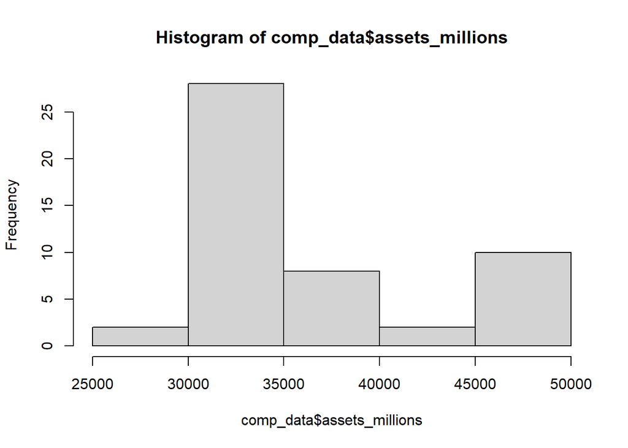

```r
hist(comp_data$assets_millions)
```

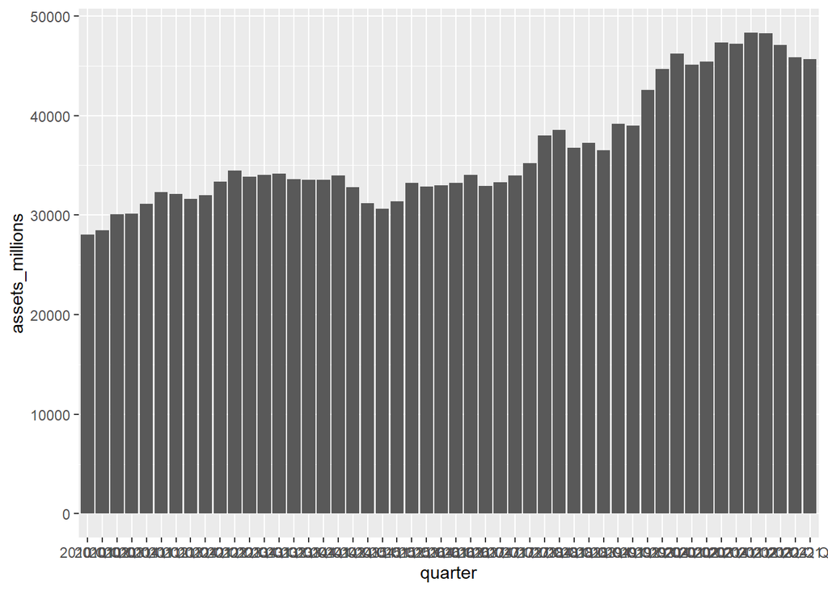

```r
#create time series plot
ggplot(comp_data,aes(x=quarter, y=assets_millions)) +
       geom_bar(stat = "identity")
```

# current ratio

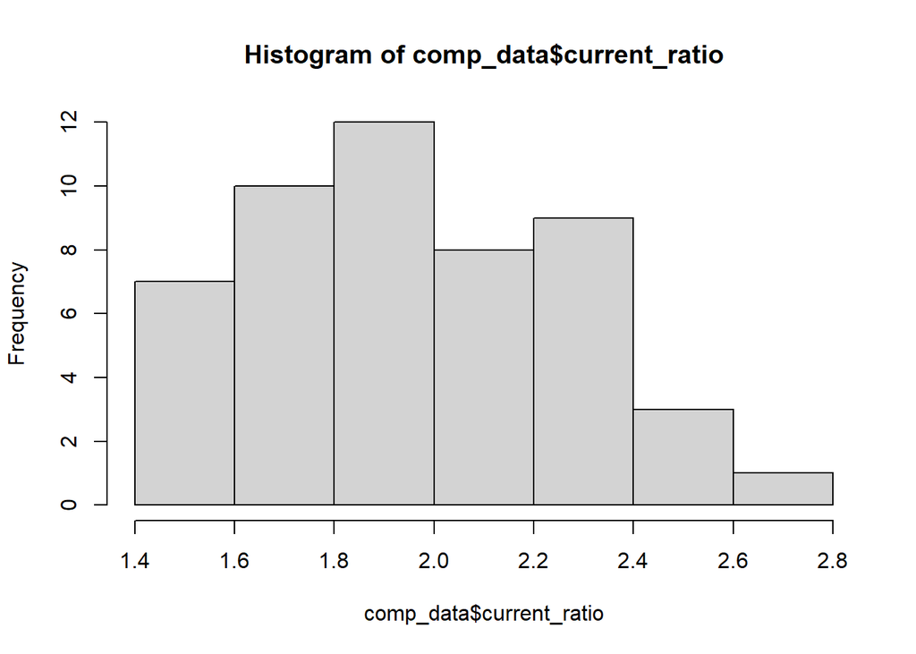

```r
hist(comp_data$current_ratio)
```

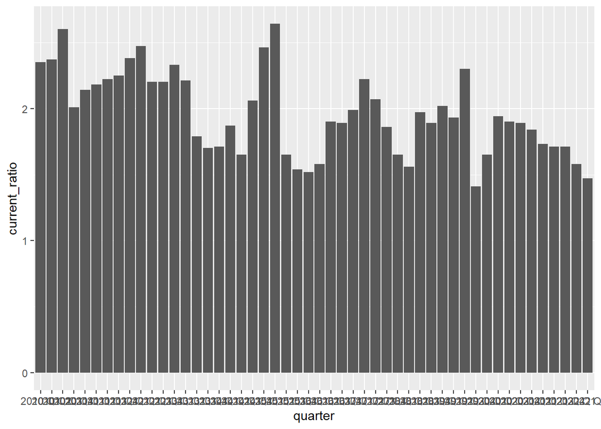

```r
#create time series plot
ggplot(comp_data,aes(x=quarter, y=current_ratio)) +
       geom_bar(stat = "identity")
```

# revenue (millions)

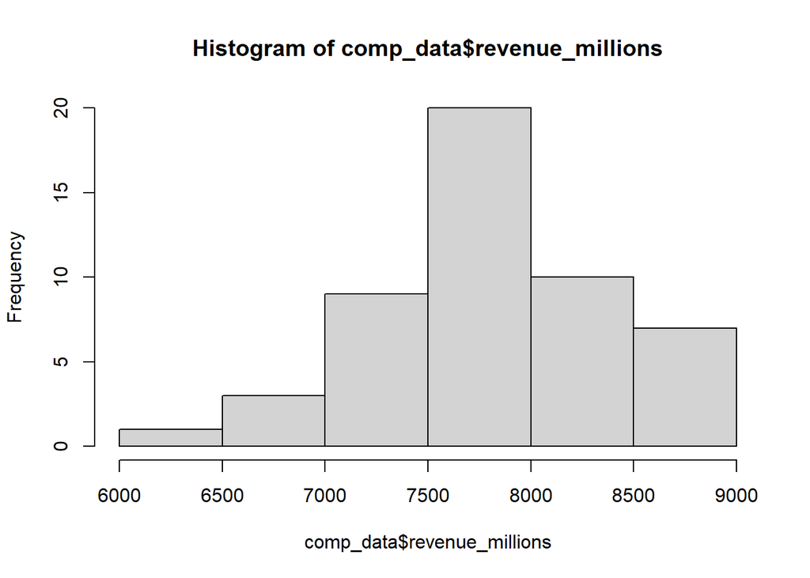

```r
hist(comp_data$revenue_millions)
```

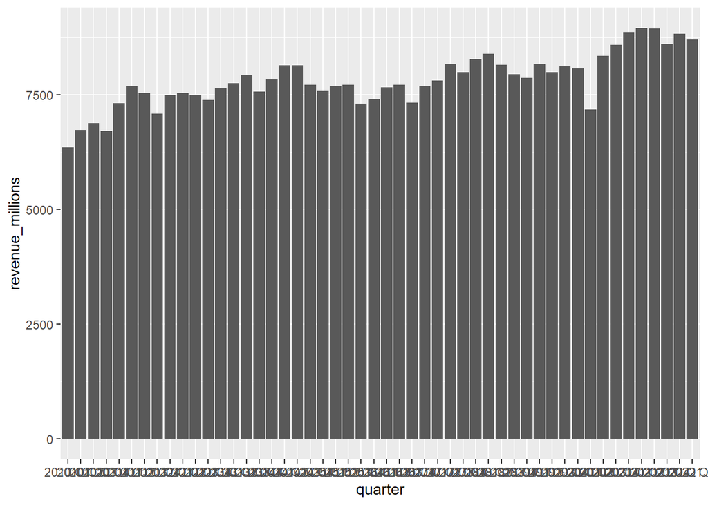

```r
#create time series plot
ggplot(comp_data,aes(x=quarter, y=revenue_millions)) +
       geom_bar(stat = "identity")
```

# net income

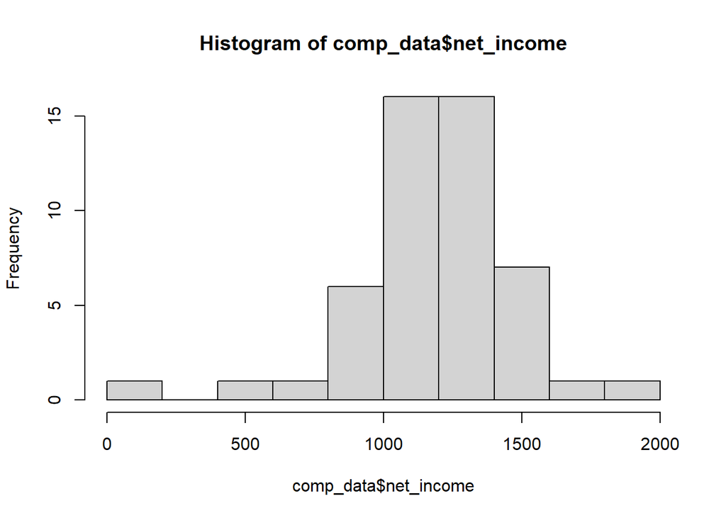

```r
hist(comp_data$net_income)
```

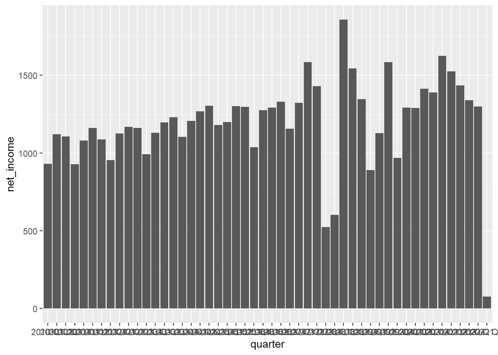

```r
#create time series plot
ggplot(comp_data, aes(x=quarter, y=net_income)) +
       geom_bar(stat = "identity")
```

# Cost of goods sold (COGS)

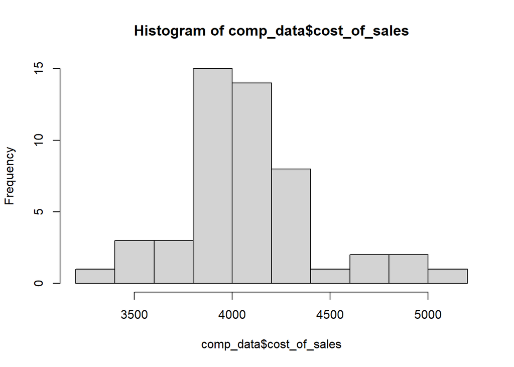

```r
hist(comp_data$cost_of_sales)
```

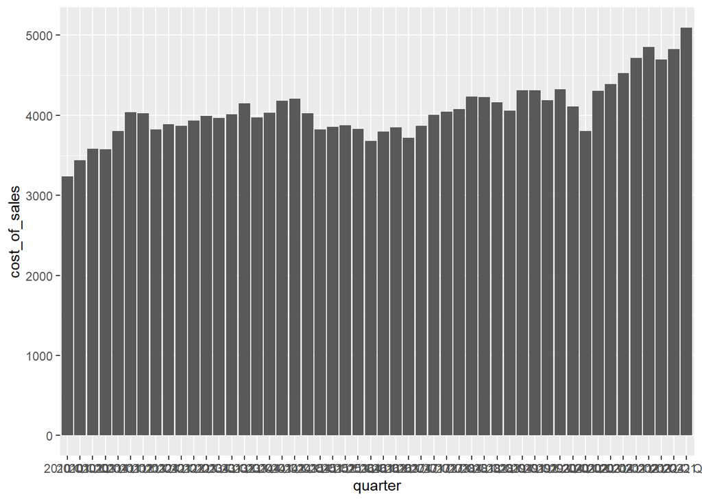

```r
#create time series plot
ggplot(comp_data, aes(x=quarter, y=cost_of_sales)) +
       geom_bar(stat = "identity")
```

# Research and Development spending

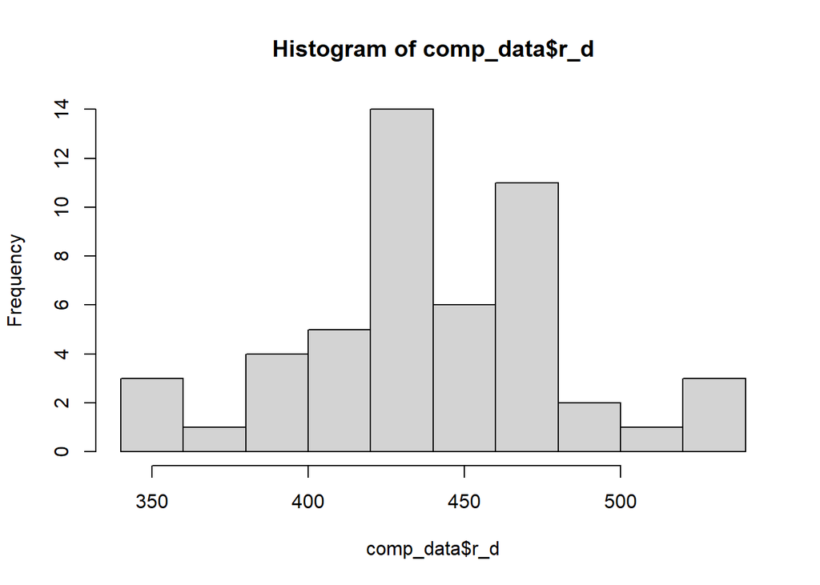

```r
hist(comp_data$r_d)
```

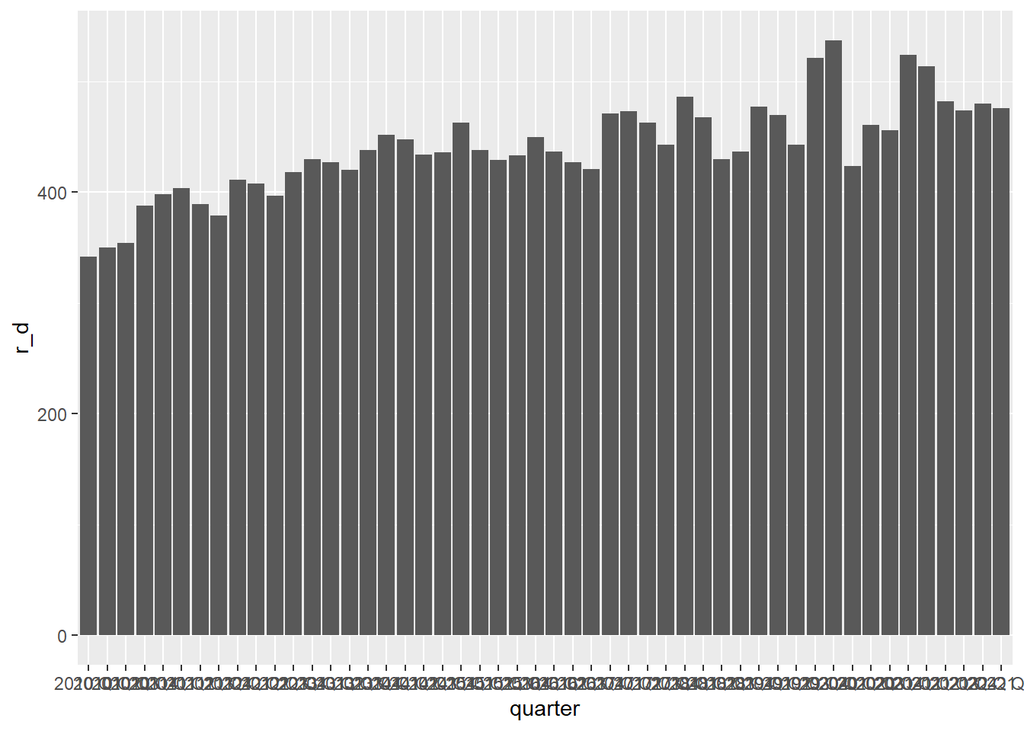

```r
#create time series plot
ggplot(comp_data, aes(x=quarter, y=r_d)) +
       geom_bar(stat = "identity")
```

# cpi

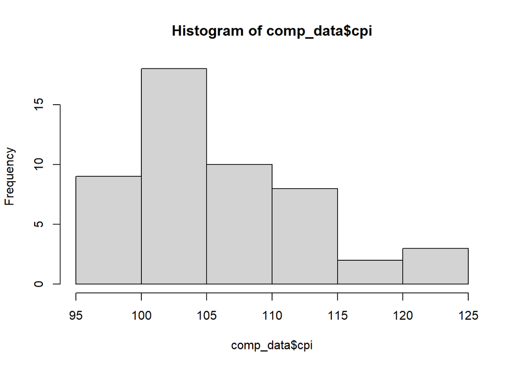

```r
hist(comp_data$cpi)
```

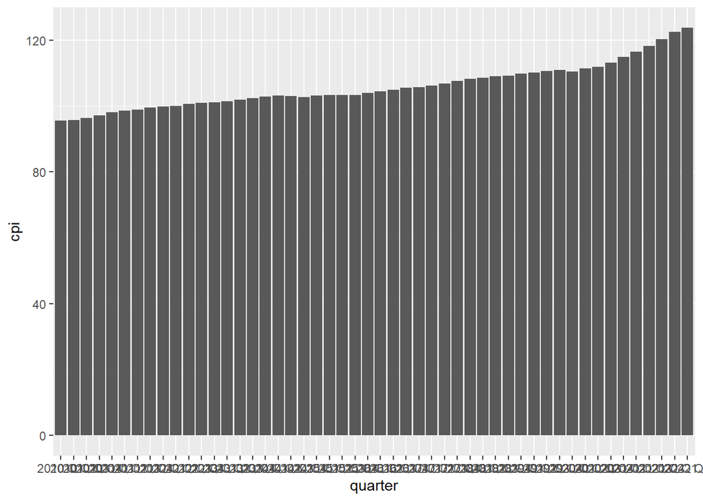

```r
#create time series plot
ggplot(comp_data, aes(x=quarter, y=cpi)) +
       geom_bar(stat = "identity")
```

# US GDP

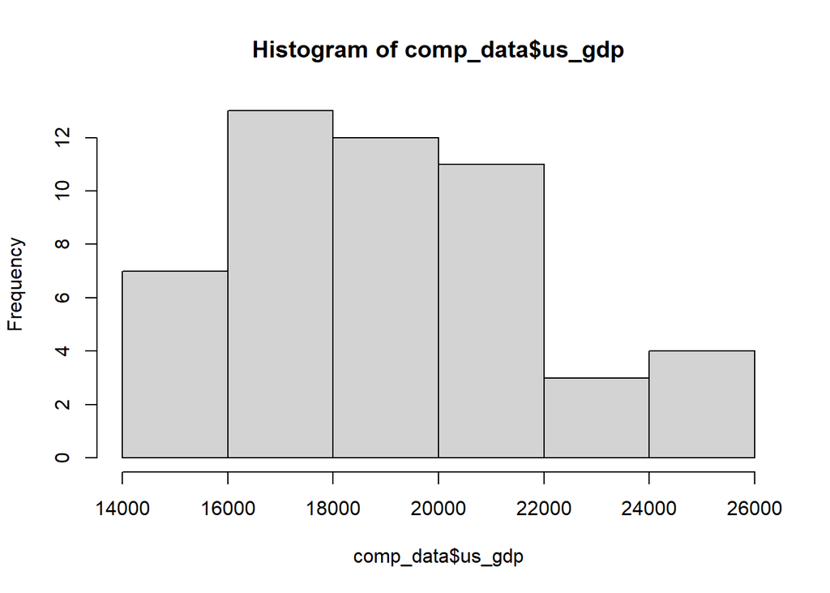

```r
hist(comp_data$us_gdp)
```

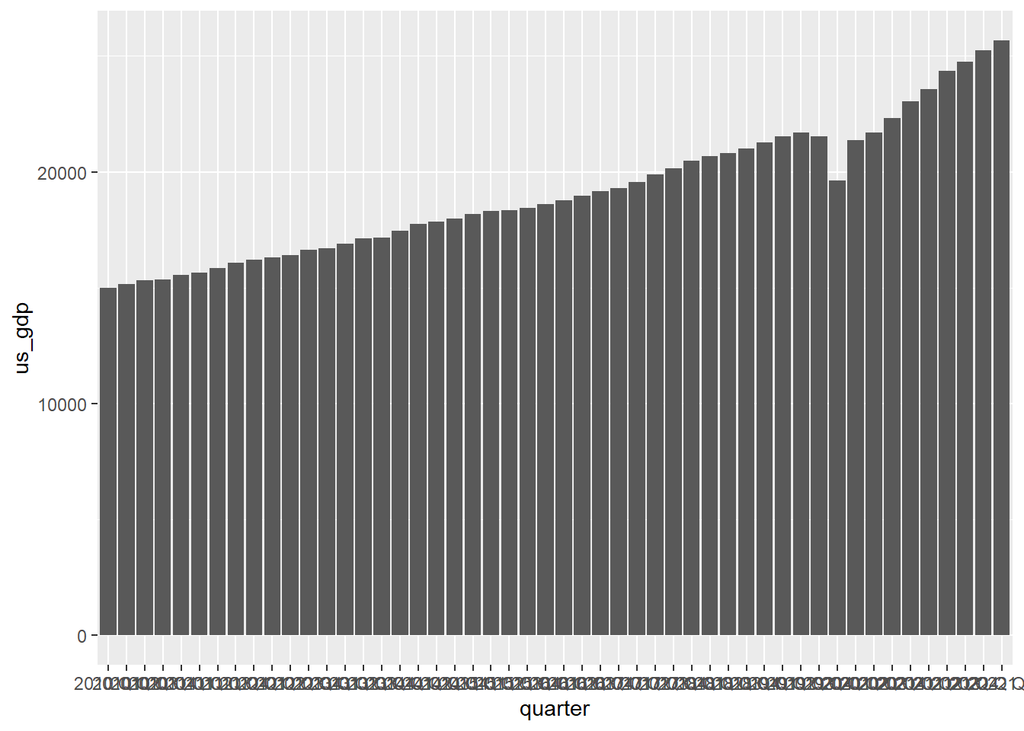

```r
#create time series plot
ggplot(comp_data,aes(x=quarter, y=us_gdp)) +
       geom_bar(stat = "identity")
```

# Standard & Poor’s 500 (SPX)

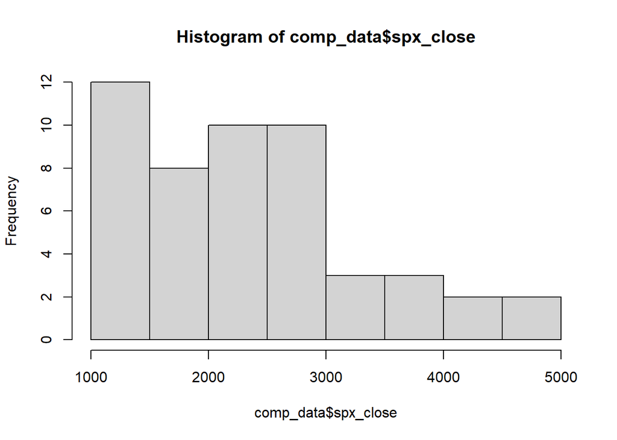

```r
hist(comp_data$spx_close)
```

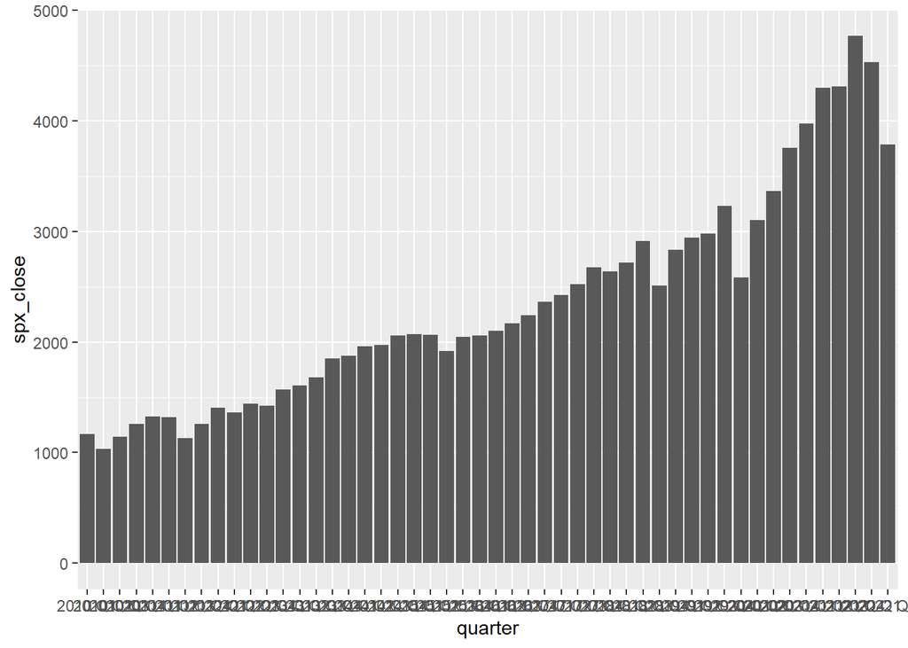

```r
#create time series plot
ggplot(comp_data,aes(x=quarter, y=spx_close)) +
       geom_bar(stat = "identity")
```

# 3M stock price (close)

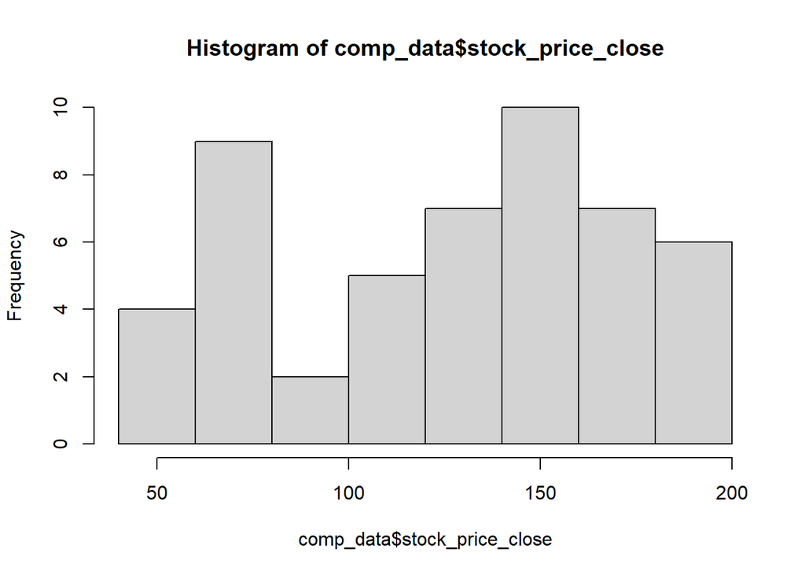

```r
hist(comp_data$stock_price_close)
```

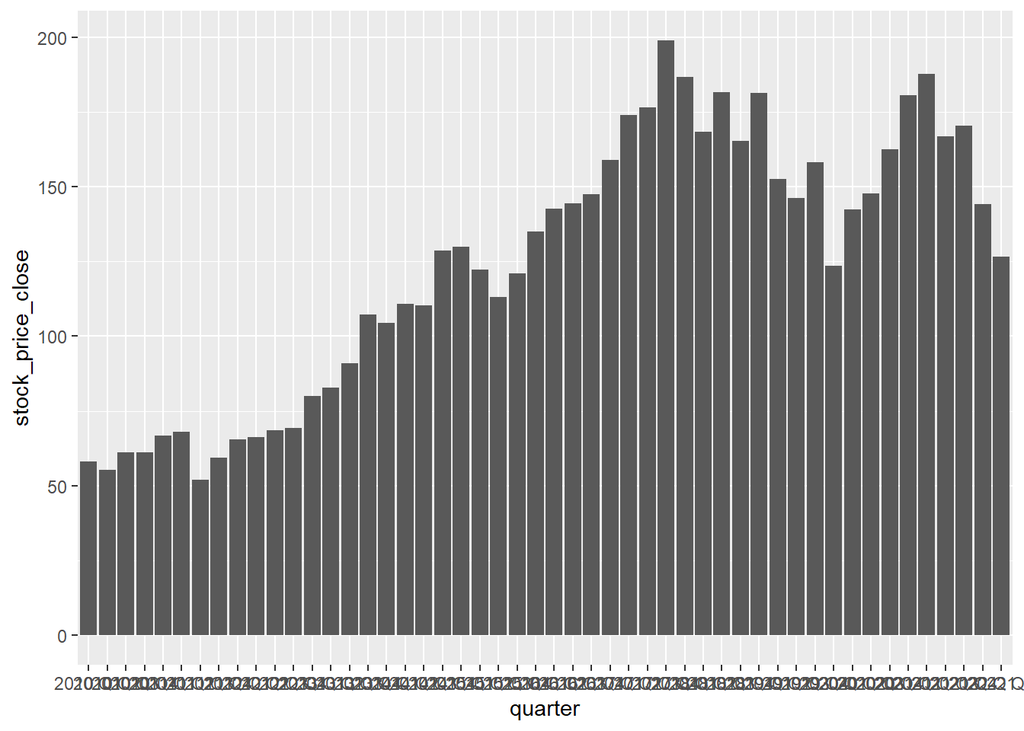

```r
#create time series plot
ggplot(comp_data,aes(x=quarter, y=stock_price_close)) +
       geom_bar(stat = "identity")
```

# Correlation

Here is a correlation matrix for the variables we used

```r
cor(comp_data[sapply(comp_data,is.numeric)])
```

```
##                   assets_millions current_ratio revenue_millions     us_gdp
## assets_millions         1.0000000   -0.50078257        0.7924779  0.8853001
## current_ratio          -0.5007826    1.00000000       -0.5318904 -0.5641682
## revenue_millions        0.7924779   -0.53189036        1.0000000  0.8324207
## us_gdp                  0.8853001   -0.56416817        0.8324207  1.0000000
## cpi                     0.9086670   -0.57533292        0.8441780  0.9886598
## spx_close               0.9111667   -0.54166504        0.8390101  0.9767728
## stock_price_close       0.6206892   -0.51007648        0.6897296  0.8084060
## net_income              0.1508431    0.02861014        0.2524694  0.1377340
## cost_of_sales           0.8158422   -0.50985220        0.9293987  0.8364715
## r_d                     0.7368136   -0.59058855        0.8098815  0.7622860
##                           cpi  spx_close stock_price_close net_income
## assets_millions    0.90866696  0.9111667         0.6206892 0.15084310
## current_ratio     -0.57533292 -0.5416650        -0.5100765 0.02861014
## revenue_millions   0.84417796  0.8390101         0.6897296 0.25246942
## us_gdp             0.98865980  0.9767728         0.8084060 0.13773401
## cpi                1.00000000  0.9706318         0.7408913 0.09887969
## spx_close          0.97063180  1.0000000         0.7872179 0.21540474
## stock_price_close  0.74089128  0.7872179         1.0000000 0.25908778
## net_income         0.09887969  0.2154047         0.2590878 1.00000000
## cost_of_sales      0.87260974  0.8296898         0.5381389 0.02485207
## r_d                0.76705326  0.7612183         0.7613257 0.20399511
##                   cost_of_sales        r_d
## assets_millions      0.81584220  0.7368136
## current_ratio       -0.50985220 -0.5905885
## revenue_millions     0.92939867  0.8098815
## us_gdp               0.83647154  0.7622860
## cpi                  0.87260974  0.7670533
## spx_close            0.82968980  0.7612183
## stock_price_close    0.53813890  0.7613257
## net_income           0.02485207  0.2039951
## cost_of_sales        1.00000000  0.7128729
## r_d                  0.71287292  1.0000000
```

# Regression models

We start with a regression model using all our variables. The target or predicted variable is the company stock price. The other variables are explanatory variables.

We found the model with all the variables was very useful in predicting the stock price. It accounts for 92% of the variation. But not all the variables appear to be significant.

```r
model <- lm(stock_price_close ~ assets_millions + current_ratio + revenue_millions + net_income + cost_of_sales + r_d + cpi+ spx_close + us_gdp, data = comp_data)

screenreg(model)
```

```
##
## =============================
##                   Model 1
## -----------------------------
## (Intercept)        596.95 **
##                   (178.81)
## assets_millions     -0.00
##                     (0.00)
## current_ratio       -2.99
##                     (8.15)
## revenue_millions     0.05 **
##                     (0.01)
## net_income          -0.02 *
##                     (0.01)
## cost_of_sales       -0.10 ***
##                     (0.02)
## r_d                  0.32 **
##                     (0.09)
## cpi                -12.01 ***
##                     (2.73)
## spx_close            0.01
##                     (0.01)
## us_gdp               0.04 ***
##                     (0.01)
## -----------------------------
## R^2                  0.92
## Adj. R^2             0.91
## Num. obs.           50
## =============================
## *** p < 0.001; ** p < 0.01; * p < 0.05
```

```r
summary(model)
```

```
##
## Call:
## lm(formula = stock_price_close ~ assets_millions + current_ratio +
##     revenue_millions + net_income + cost_of_sales + r_d + cpi +
##     spx_close + us_gdp, data = comp_data)
##
## Residuals:
##     Min      1Q  Median      3Q     Max
## -20.243  -9.131  -0.897   6.069  32.215
##
## Coefficients:
##                    Estimate Std. Error t value Pr(>|t|)
## (Intercept)       5.970e+02  1.788e+02   3.339 0.001830 **
## assets_millions  -1.410e-03  9.089e-04  -1.551 0.128799
## current_ratio    -2.994e+00  8.153e+00  -0.367 0.715416
## revenue_millions  5.018e-02  1.478e-02   3.394 0.001565 **
## net_income       -2.021e-02  9.572e-03  -2.111 0.041030 *
## cost_of_sales    -9.585e-02  2.418e-02  -3.963 0.000297 ***
## r_d               3.235e-01  9.273e-02   3.489 0.001194 **
## cpi              -1.201e+01  2.734e+00  -4.391 8.04e-05 ***
## spx_close         1.382e-02  1.154e-02   1.197 0.238364
## us_gdp            3.676e-02  6.134e-03   5.992 4.85e-07 ***
## ---
## Signif. codes:  0 '***' 0.001 '**' 0.01 '*' 0.05 '.' 0.1 ' ' 1
##
## Residual standard error: 13.6 on 40 degrees of freedom
## Multiple R-squared:  0.9227, Adjusted R-squared:  0.9053
## F-statistic: 53.04 on 9 and 40 DF,  p-value: < 2.2e-16
```

# Remove current ratio

The current ratio looks like it is the least significant variable, based on the p and t values.

So let’s try a new regression model without that variable. The new simpler model still lets us account for 92% of the variation.

```r
model <- lm(stock_price_close ~ assets_millions  + revenue_millions + net_income + cost_of_sales + r_d + cpi+ spx_close + us_gdp, data = comp_data)

screenreg(model)
```

```
##
## =============================
##                   Model 1
## -----------------------------
## (Intercept)        577.33 **
##                   (168.83)
## assets_millions     -0.00
##                     (0.00)
## revenue_millions     0.05 **
##                     (0.01)
## net_income          -0.02 *
##                     (0.01)
## cost_of_sales       -0.10 ***
##                     (0.02)
## r_d                  0.33 ***
##                     (0.09)
## cpi                -11.87 ***
##                     (2.68)
## spx_close            0.01
##                     (0.01)
## us_gdp               0.04 ***
##                     (0.01)
## -----------------------------
## R^2                  0.92
## Adj. R^2             0.91
## Num. obs.           50
## =============================
## *** p < 0.001; ** p < 0.01; * p < 0.05
```

```r
summary(model)
```

```
##
## Call:
## lm(formula = stock_price_close ~ assets_millions + revenue_millions +
##     net_income + cost_of_sales + r_d + cpi + spx_close + us_gdp,
##     data = comp_data)
##
## Residuals:
##     Min      1Q  Median      3Q     Max
## -19.522  -9.930   0.002   6.017  31.983
##
## Coefficients:
##                    Estimate Std. Error t value Pr(>|t|)
## (Intercept)       5.773e+02  1.688e+02   3.420 0.001430 **
## assets_millions  -1.436e-03  8.965e-04  -1.601 0.116952
## revenue_millions  5.076e-02  1.454e-02   3.491 0.001167 **
## net_income       -2.081e-02  9.331e-03  -2.231 0.031228 *
## cost_of_sales    -9.691e-02  2.376e-02  -4.079 0.000203 ***
## r_d               3.311e-01  8.943e-02   3.703 0.000629 ***
## cpi              -1.187e+01  2.679e+00  -4.430 6.87e-05 ***
## spx_close         1.378e-02  1.142e-02   1.207 0.234384
## us_gdp            3.661e-02  6.057e-03   6.045 3.74e-07 ***
## ---
## Signif. codes:  0 '***' 0.001 '**' 0.01 '*' 0.05 '.' 0.1 ' ' 1
##
## Residual standard error: 13.45 on 41 degrees of freedom
## Multiple R-squared:  0.9224, Adjusted R-squared:  0.9073
## F-statistic: 60.94 on 8 and 41 DF,  p-value: < 2.2e-16
```

# Remove S&P 500

The S&P 500 index is also not significant, based on the p and t values.

So let’s try removing that variable.

Our model still accounts for 92% of the variation

```r
model <- lm(stock_price_close ~ assets_millions +  revenue_millions +  cost_of_sales + r_d + cpi+ net_income + us_gdp, data = comp_data)

screenreg(model)
```

```
##
## =============================
##                   Model 1
## -----------------------------
## (Intercept)        509.72 **
##                   (160.12)
## assets_millions     -0.00
##                     (0.00)
## revenue_millions     0.05 **
##                     (0.01)
## cost_of_sales       -0.10 ***
##                     (0.02)
## r_d                  0.32 ***
##                     (0.09)
## cpi                -11.74 ***
##                     (2.69)
## net_income          -0.02
##                     (0.01)
## us_gdp               0.04 ***
##                     (0.01)
## -----------------------------
## R^2                  0.92
## Adj. R^2             0.91
## Num. obs.           50
## =============================
## *** p < 0.001; ** p < 0.01; * p < 0.05
```

```r
summary(model)
```

```
##
## Call:
## lm(formula = stock_price_close ~ assets_millions + revenue_millions +
##     cost_of_sales + r_d + cpi + net_income + us_gdp, data = comp_data)
##
## Residuals:
##     Min      1Q  Median      3Q     Max
## -21.051 -10.205   0.294   6.774  34.251
##
## Coefficients:
##                    Estimate Std. Error t value Pr(>|t|)
## (Intercept)       5.097e+02  1.601e+02   3.183 0.002741 **
## assets_millions  -9.914e-04  8.219e-04  -1.206 0.234472
## revenue_millions  5.160e-02  1.460e-02   3.533 0.001013 **
## cost_of_sales    -9.757e-02  2.388e-02  -4.086 0.000193 ***
## r_d               3.244e-01  8.974e-02   3.615 0.000798 ***
## cpi              -1.174e+01  2.691e+00  -4.363 8.17e-05 ***
## net_income       -1.735e-02  8.925e-03  -1.943 0.058678 .
## us_gdp            4.004e-02  5.378e-03   7.446 3.37e-09 ***
## ---
## Signif. codes:  0 '***' 0.001 '**' 0.01 '*' 0.05 '.' 0.1 ' ' 1
##
## Residual standard error: 13.52 on 42 degrees of freedom
## Multiple R-squared:  0.9197, Adjusted R-squared:  0.9063
## F-statistic: 68.69 on 7 and 42 DF,  p-value: < 2.2e-16
```

# Remove net income

Net income is also not significant, based on the p and t values.

So let’s try removing that next.

Our model still predicts 91% of the variation and is simpler.

```r
model <- lm(stock_price_close ~ assets_millions +  revenue_millions +  cost_of_sales + r_d + cpi+  us_gdp, data = comp_data)

screenreg(model)
```

```
##
## =============================
##                   Model 1
## -----------------------------
## (Intercept)        497.57 **
##                   (165.09)
## assets_millions     -0.00
##                     (0.00)
## revenue_millions     0.04 **
##                     (0.01)
## cost_of_sales       -0.07 **
##                     (0.02)
## r_d                  0.36 ***
##                     (0.09)
## cpi                -11.53 ***
##                     (2.77)
## us_gdp               0.04 ***
##                     (0.01)
## -----------------------------
## R^2                  0.91
## Adj. R^2             0.90
## Num. obs.           50
## =============================
## *** p < 0.001; ** p < 0.01; * p < 0.05
```

```r
summary(model)
```

```
##
## Call:
## lm(formula = stock_price_close ~ assets_millions + revenue_millions +
##     cost_of_sales + r_d + cpi + us_gdp, data = comp_data)
##
## Residuals:
##     Min      1Q  Median      3Q     Max
## -20.331  -8.796  -0.428   6.243  48.766
##
## Coefficients:
##                    Estimate Std. Error t value Pr(>|t|)
## (Intercept)       4.976e+02  1.651e+02   3.014 0.004312 **
## assets_millions  -1.313e-03  8.307e-04  -1.580 0.121341
## revenue_millions  3.533e-02  1.235e-02   2.862 0.006486 **
## cost_of_sales    -7.319e-02  2.097e-02  -3.491 0.001127 **
## r_d               3.586e-01  9.079e-02   3.950 0.000286 ***
## cpi              -1.153e+01  2.775e+00  -4.155 0.000152 ***
## us_gdp            3.970e-02  5.546e-03   7.159 7.57e-09 ***
## ---
## Signif. codes:  0 '***' 0.001 '**' 0.01 '*' 0.05 '.' 0.1 ' ' 1
##
## Residual standard error: 13.95 on 43 degrees of freedom
## Multiple R-squared:  0.9124, Adjusted R-squared:  0.9002
## F-statistic: 74.68 on 6 and 43 DF,  p-value: < 2.2e-16
```

# Remove assets (in millions)

Assets are also not significant in our model, based on the p and t values.

So let’s remove that one next.

Our model still predicts 91% of the variation and is simpler.

```r
model <- lm(stock_price_close ~   revenue_millions +  cost_of_sales + r_d + cpi+  us_gdp, data = comp_data)

screenreg(model)
```

```
##
## =============================
##                   Model 1
## -----------------------------
## (Intercept)        604.45 ***
##                   (153.14)
## revenue_millions     0.03 **
##                     (0.01)
## cost_of_sales       -0.07 **
##                     (0.02)
## r_d                  0.34 ***
##                     (0.09)
## cpi                -13.21 ***
##                     (2.61)
## us_gdp               0.04 ***
##                     (0.01)
## -----------------------------
## R^2                  0.91
## Adj. R^2             0.90
## Num. obs.           50
## =============================
## *** p < 0.001; ** p < 0.01; * p < 0.05
```

```r
summary(model)
```

```
##
## Call:
## lm(formula = stock_price_close ~ revenue_millions + cost_of_sales +
##     r_d + cpi + us_gdp, data = comp_data)
##
## Residuals:
##     Min      1Q  Median      3Q     Max
## -22.172  -8.715  -0.689   5.861  48.034
##
## Coefficients:
##                    Estimate Std. Error t value Pr(>|t|)
## (Intercept)      604.449632 153.139812   3.947 0.000281 ***
## revenue_millions   0.034442   0.012540   2.746 0.008696 **
## cost_of_sales     -0.072278   0.021312  -3.391 0.001479 **
## r_d                0.343480   0.091808   3.741 0.000527 ***
## cpi              -13.212542   2.605257  -5.071 7.61e-06 ***
## us_gdp             0.041448   0.005526   7.500 2.13e-09 ***
## ---
## Signif. codes:  0 '***' 0.001 '**' 0.01 '*' 0.05 '.' 0.1 ' ' 1
##
## Residual standard error: 14.19 on 44 degrees of freedom
## Multiple R-squared:  0.9074, Adjusted R-squared:  0.8968
## F-statistic: 86.19 on 5 and 44 DF,  p-value: < 2.2e-16
```

# Remove revenue (in millions)

Revenue is the least significant of the remaining variables, based on the p and t values.

So let’s remove that one next.

Our model now predicts 89% of the variation, so it is slowly getting less accurate with fewer variables.

```r
model <- lm(stock_price_close ~    cost_of_sales + r_d + cpi+  us_gdp, data = comp_data)

screenreg(model)
```

```
##
## ==========================
##                Model 1
## --------------------------
## (Intercept)     803.85 ***
##                (144.30)
## cost_of_sales    -0.03
##                  (0.01)
## r_d               0.48 ***
##                  (0.08)
## cpi             -16.01 ***
##                  (2.57)
## us_gdp            0.05 ***
##                  (0.01)
## --------------------------
## R^2               0.89
## Adj. R^2          0.88
## Num. obs.        50
## ==========================
## *** p < 0.001; ** p < 0.01; * p < 0.05
```

```r
summary(model)
```

```
##
## Call:
## lm(formula = stock_price_close ~ cost_of_sales + r_d + cpi +
##     us_gdp, data = comp_data)
##
## Residuals:
##     Min      1Q  Median      3Q     Max
## -32.328  -9.147   1.112   7.217  51.628
##
## Coefficients:
##                 Estimate Std. Error t value Pr(>|t|)
## (Intercept)   803.854905 144.304139   5.571 1.35e-06 ***
## cost_of_sales  -0.025088   0.013493  -1.859   0.0695 .
## r_d             0.484207   0.081529   5.939 3.84e-07 ***
## cpi           -16.006438   2.566887  -6.236 1.39e-07 ***
## us_gdp          0.047298   0.005457   8.667 3.77e-11 ***
## ---
## Signif. codes:  0 '***' 0.001 '**' 0.01 '*' 0.05 '.' 0.1 ' ' 1
##
## Residual standard error: 15.19 on 45 degrees of freedom
## Multiple R-squared:  0.8915, Adjusted R-squared:  0.8818
## F-statistic: 92.41 on 4 and 45 DF,  p-value: < 2.2e-16
```

# Remove cost of goods sold

cost of good sold is no longer significant, based on the p and t values.

So let’s remove that one next.

Our model now predicts 88% of the variation – with only three variables left

```r
model <- lm(stock_price_close ~    r_d + cpi+  us_gdp, data = comp_data)

screenreg(model)
```

```
##
## ========================
##              Model 1
## ------------------------
## (Intercept)   915.82 ***
##              (134.59)
## r_d             0.46 ***
##                (0.08)
## cpi           -18.60 ***
##                (2.21)
## us_gdp          0.05 ***
##                (0.01)
## ------------------------
## R^2             0.88
## Adj. R^2        0.88
## Num. obs.      50
## ========================
## *** p < 0.001; ** p < 0.01; * p < 0.05
```

```r
summary(model)
```

```
##
## Call:
## lm(formula = stock_price_close ~ r_d + cpi + us_gdp, data = comp_data)
##
## Residuals:
##     Min      1Q  Median      3Q     Max
## -32.808  -8.955  -0.295   8.079  51.807
##
## Coefficients:
##              Estimate Std. Error t value Pr(>|t|)
## (Intercept) 915.82443  134.59443   6.804 1.79e-08 ***
## r_d           0.45926    0.08254   5.564 1.30e-06 ***
## cpi         -18.59576    2.21311  -8.403 7.60e-11 ***
## us_gdp        0.05103    0.00521   9.794 7.85e-13 ***
## ---
## Signif. codes:  0 '***' 0.001 '**' 0.01 '*' 0.05 '.' 0.1 ' ' 1
##
## Residual standard error: 15.59 on 46 degrees of freedom
## Multiple R-squared:  0.8831, Adjusted R-squared:  0.8755
## F-statistic: 115.9 on 3 and 46 DF,  p-value: < 2.2e-16
```

# Remove research and development expense

All the remaining variables are significant in our model. But the least significant is R&D expense, based on the p and t values.

So let’s remove that one next.

That leaves us with just CPI and us GDP. But our model can still explain 80 percent of the variation.

```r
model <- lm(stock_price_close ~    cpi+  us_gdp, data = comp_data)

screenreg(model)
```

```
##
## ========================
##              Model 1
## ------------------------
## (Intercept)   915.54 ***
##              (172.23)
## cpi           -16.90 ***
##                (2.80)
## us_gdp          0.05 ***
##                (0.01)
## ------------------------
## R^2             0.80
## Adj. R^2        0.80
## Num. obs.      50
## ========================
## *** p < 0.001; ** p < 0.01; * p < 0.05
```

```r
summary(model)
```

```
##
## Call:
## lm(formula = stock_price_close ~ cpi + us_gdp, data = comp_data)
##
## Residuals:
##     Min      1Q  Median      3Q     Max
## -38.325 -11.394  -1.577  10.739  48.895
##
## Coefficients:
##               Estimate Std. Error t value Pr(>|t|)
## (Intercept) 915.537498 172.232543   5.316 2.87e-06 ***
## cpi         -16.896569   2.804893  -6.024 2.48e-07 ***
## us_gdp        0.052208   0.006661   7.838 4.45e-10 ***
## ---
## Signif. codes:  0 '***' 0.001 '**' 0.01 '*' 0.05 '.' 0.1 ' ' 1
##
## Residual standard error: 19.95 on 47 degrees of freedom
## Multiple R-squared:  0.8045, Adjusted R-squared:  0.7962
## F-statistic: 96.69 on 2 and 47 DF,  p-value: < 2.2e-16
```

# Remove cpi

Finally, the Consumer Price Index is the least significant of our remaining two variables.

So let’s remove that one as well. That leaves us with only US GDP to predict 3M’s stock price. But our model can still predict 65% of the variation in 3M’s stock price.

That suggests the US GDP is the biggest driver of 3M’s stock price among the explanatory variables we examined.

```r
model <- lm(stock_price_close ~   us_gdp, data = comp_data)

screenreg(model)
```

```
##
## ========================
##              Model 1
## ------------------------
## (Intercept)  -115.42 ***
##               (25.49)
## us_gdp          0.01 ***
##                (0.00)
## ------------------------
## R^2             0.65
## Adj. R^2        0.65
## Num. obs.      50
## ========================
## *** p < 0.001; ** p < 0.01; * p < 0.05
```

```r
summary(model)
```

```
##
## Call:
## lm(formula = stock_price_close ~ us_gdp, data = comp_data)
##
## Residuals:
##     Min      1Q  Median      3Q     Max
## -79.722 -15.064  -1.509  17.289  61.560
##
## Coefficients:
##               Estimate Std. Error t value Pr(>|t|)
## (Intercept) -1.154e+02  2.549e+01  -4.529 3.93e-05 ***
## us_gdp       1.254e-02  1.318e-03   9.515 1.26e-12 ***
## ---
## Signif. codes:  0 '***' 0.001 '**' 0.01 '*' 0.05 '.' 0.1 ' ' 1
##
## Residual standard error: 26.27 on 48 degrees of freedom
## Multiple R-squared:  0.6535, Adjusted R-squared:  0.6463
## F-statistic: 90.54 on 1 and 48 DF,  p-value: 1.257e-12
```